# Data Frames

Vamos a descargar de la pagina de UCI Machine Learning repository la base de datos de Adults.

Lo primero que hay que verificar es nuestro directorio actual de trabajo y modificarlo si necesario.

```r
getwd() # directorio actual
```

```
[1] "C:/Users/mbtec/Documents/GitHub/PropedeuticoDataScience2017/CuadernosR/2_realdata"
```

Con el comando `setwd` pondemos cambiar el directorio de trabajo. Por ejemplo

```r
# setwd("C:/Users/mbtec/Documents/GitHub/PropedeuticoDataScience2017/CuadernosR/Cuaderno2")
```

En RStudio la maneta facil tambien es dar click en los 3 puntos `...` que aparecen en la ventana de Files, navegar al destino, y luego dar click en `More` y seleccionar la opcion `Set As Working Directory`. Alternativamente (mas facil) en el menu principal en `Session`. Otra opcion es trabajar siempre con proyectos que “fijan” el working directory. El working directory lo pueden cambiar cuantas veces quieran.

### Bajar los datos

```r
download.file("https://archive.ics.uci.edu/ml/machine-learning-databases/adult/adult.data", "adultsdata.csv")
```

Alternativamente se puede descargar manualmente. Ahora hay que leerlo en R.

```r
adults <- read.csv("adultsdata.csv", header = FALSE)
head(adults) # imprime las primeras lineas
```

|  | V1 | V2 | V3 | V4 | V5 | V6 | V7 | V8 | V9 | V10 | V11 | V12 | V13 | V14 | V15 |
| --- | --- | --- | --- | --- | --- | --- | --- | --- | --- | --- | --- | --- | --- | --- | --- |
| 1 | 39 | State-gov | 77516 | Bachelors | 13 | Never-married | Adm-clerical | Not-in-family | White | Male | 2174 | 0 | 40 | United-States | <=50K |
| 2 | 50 | Self-emp-not-inc | 83311 | Bachelors | 13 | Married-civ-spouse | Exec-managerial | Husband | White | Male | 0 | 0 | 13 | United-States | <=50K |
| 3 | 38 | Private | 215646 | HS-grad | 9 | Divorced | Handlers-cleaners | Not-in-family | White | Male | 0 | 0 | 40 | United-States | <=50K |
| 4 | 53 | Private | 234721 | 11th | 7 | Married-civ-spouse | Handlers-cleaners | Husband | Black | Male | 0 | 0 | 40 | United-States | <=50K |
| 5 | 28 | Private | 338409 | Bachelors | 13 | Married-civ-spouse | Prof-specialty | Wife | Black | Female | 0 | 0 | 40 | Cuba | <=50K |
| 6 | 37 | Private | 284582 | Masters | 14 | Married-civ-spouse | Exec-managerial | Wife | White | Female | 0 | 0 | 40 | United-States | <=50K |

Podemos accesar a las variables por numero de columna o por nombre. En este caso como usamos `header = FALSE` automaticamente R eligio los nombres V1, V2, etc.

Manualmente podemos elegir nombres

```r
names(adults) <-  c("age", "workclass", "fnlwgt", "education", "education_num", "marital_status", "occupation", "relationship", "race", "sex", "capital_gain", "capital_loss", "hours_per_week", "native_country","uji")
head(adults)
```

|  | age | workclass | fnlwgt | education | education_num | marital_status | occupation | relationship | race | sex | capital_gain | capital_loss | hours_per_week | native_country | uji |
| --- | --- | --- | --- | --- | --- | --- | --- | --- | --- | --- | --- | --- | --- | --- | --- |
| 1 | 39 | State-gov | 77516 | Bachelors | 13 | Never-married | Adm-clerical | Not-in-family | White | Male | 2174 | 0 | 40 | United-States | <=50K |
| 2 | 50 | Self-emp-not-inc | 83311 | Bachelors | 13 | Married-civ-spouse | Exec-managerial | Husband | White | Male | 0 | 0 | 13 | United-States | <=50K |
| 3 | 38 | Private | 215646 | HS-grad | 9 | Divorced | Handlers-cleaners | Not-in-family | White | Male | 0 | 0 | 40 | United-States | <=50K |
| 4 | 53 | Private | 234721 | 11th | 7 | Married-civ-spouse | Handlers-cleaners | Husband | Black | Male | 0 | 0 | 40 | United-States | <=50K |
| 5 | 28 | Private | 338409 | Bachelors | 13 | Married-civ-spouse | Prof-specialty | Wife | Black | Female | 0 | 0 | 40 | Cuba | <=50K |
| 6 | 37 | Private | 284582 | Masters | 14 | Married-civ-spouse | Exec-managerial | Wife | White | Female | 0 | 0 | 40 | United-States | <=50K |

Para accesar los datos pueden usar `$` o `[[]]` como en listas.

```r
table(adults$native_country)
```

```
                          ?                    Cambodia
                        583                          19
                     Canada                       China
                        121                          75
                   Columbia                        Cuba
                         59                          95
         Dominican-Republic                     Ecuador
                         70                          28
                El-Salvador                     England
                        106                          90
                     France                     Germany
                         29                         137
                     Greece                   Guatemala
                         29                          64
                      Haiti          Holand-Netherlands
                         44                           1
                   Honduras                        Hong
                         13                          20
                    Hungary                       India
                         13                         100
                       Iran                     Ireland
                         43                          24
                      Italy                     Jamaica
                         73                          81
                      Japan                        Laos
                         62                          18
                     Mexico                   Nicaragua
                        643                          34
 Outlying-US(Guam-USVI-etc)                        Peru
                         14                          31
                Philippines                      Poland
                        198                          60
                   Portugal                 Puerto-Rico
                         37                         114
                   Scotland                       South
                         12                          80
                     Taiwan                    Thailand
                         51                          18
            Trinadad&Tobago               United-States
                         19                       29170
                    Vietnam                  Yugoslavia
                         67                          16
```

En general pueden saber mucho de un data frame con la funcion summary (en teoria, pero nunca le he encontrado practica…)

```r
summary(adults)
```

```
      age                    workclass         fnlwgt
 Min.   :17.00    Private         :22696   Min.   :  12285
 1st Qu.:28.00    Self-emp-not-inc: 2541   1st Qu.: 117827
 Median :37.00    Local-gov       : 2093   Median : 178356
 Mean   :38.58    ?               : 1836   Mean   : 189778
 3rd Qu.:48.00    State-gov       : 1298   3rd Qu.: 237051
 Max.   :90.00    Self-emp-inc    : 1116   Max.   :1484705
                 (Other)          :  981
         education     education_num
  HS-grad     :10501   Min.   : 1.00
  Some-college: 7291   1st Qu.: 9.00
  Bachelors   : 5355   Median :10.00
  Masters     : 1723   Mean   :10.08
  Assoc-voc   : 1382   3rd Qu.:12.00
  11th        : 1175   Max.   :16.00
 (Other)      : 5134
                marital_status             occupation
  Divorced             : 4443    Prof-specialty :4140
  Married-AF-spouse    :   23    Craft-repair   :4099
  Married-civ-spouse   :14976    Exec-managerial:4066
  Married-spouse-absent:  418    Adm-clerical   :3770
  Never-married        :10683    Sales          :3650
  Separated            : 1025    Other-service  :3295
  Widowed              :  993   (Other)         :9541
          relationship                    race
  Husband       :13193    Amer-Indian-Eskimo:  311
  Not-in-family : 8305    Asian-Pac-Islander: 1039
  Other-relative:  981    Black             : 3124
  Own-child     : 5068    Other             :  271
  Unmarried     : 3446    White             :27816
  Wife          : 1568

      sex         capital_gain    capital_loss    hours_per_week
  Female:10771   Min.   :    0   Min.   :   0.0   Min.   : 1.00
  Male  :21790   1st Qu.:    0   1st Qu.:   0.0   1st Qu.:40.00
                 Median :    0   Median :   0.0   Median :40.00
                 Mean   : 1078   Mean   :  87.3   Mean   :40.44
                 3rd Qu.:    0   3rd Qu.:   0.0   3rd Qu.:45.00
                 Max.   :99999   Max.   :4356.0   Max.   :99.00

        native_country      uji
  United-States:29170    <=50K:24720
  Mexico       :  643    >50K : 7841
  ?            :  583
  Philippines  :  198
  Germany      :  137
  Canada       :  121
 (Other)       : 1709
```

### Analisis de covarianzas

[output not shown]

Vamos a ver la matriz de covarianzas:

```r
cov(adults2)
```

```
                      age education_num hours_per_week uji_numeric
age            186.061400     1.2818493      11.580130   1.3649972
education_num    1.281849     6.6188899       4.705338   0.3686853
hours_per_week  11.580130     4.7053379     152.458995   1.2126508
uji_numeric      1.364997     0.3686853       1.212651   0.1828259
```

La matriz de covarianzas no es muy util…. Es mas util ver correlaciones

```r
cor(adults2)
```

```
                      age education_num hours_per_week uji_numeric
age            1.00000000    0.03652719     0.06875571   0.2340371
education_num  0.03652719    1.00000000     0.14812273   0.3351540
hours_per_week 0.06875571    0.14812273     1.00000000   0.2296891
uji_numeric    0.23403710    0.33515395     0.22968907   1.0000000
```

Otra manera de visualizarlo

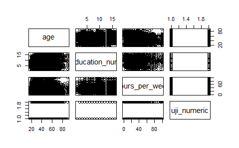

### Podrian predecir el ingreso con la edad, educacion y horas trabajas?

Para esto se usan las regresiones lineales (mas detalles manana y jueves)

```r
summary(mod)
```

```
Call:
lm(formula = uji_numeric ~ ., data = adults2)

Residuals:
    Min      1Q  Median      3Q     Max
-1.0123 -0.2703 -0.1310  0.2109  1.2272

Coefficients:
                Estimate Std. Error t value Pr(>|t|)
(Intercept)    0.2403725  0.0117049   20.54   <2e-16 ***
age            0.0066230  0.0001568   42.24   <2e-16 ***
education_num  0.0502245  0.0008386   59.89   <2e-16 ***
hours_per_week 0.0059008  0.0001750   33.71   <2e-16 ***
---
Signif. codes:  0 ‘***’ 0.001 ‘**’ 0.01 ‘*’ 0.05 ‘.’ 0.1 ‘ ’ 1

Residual standard error: 0.3849 on 32557 degrees of freedom
Multiple R-squared:  0.1899,    Adjusted R-squared:  0.1898
F-statistic:  2543 on 3 and 32557 DF,  p-value: < 2.2e-16
```

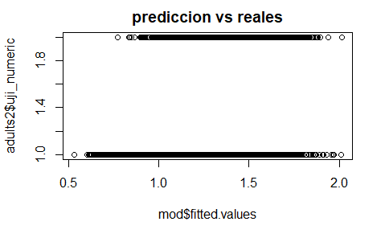

```r
plot(
  mod$fitted.values,
  adults2$uji_numeric,
  main = "prediccion vs reales"
)
```

### A mano

```r
beta
```

```
                      [,1]
age            0.006623001
education_num  0.050224476
hours_per_week 0.005900816
ones           0.240372483
```